# Bank Customer Churn Analysis using Support Vector Machines

### Introduction

In the rapidly evolving landscape of the banking industry, maintaining a strong customer base is vital for sustaining growth and profitability. Customer churn, referring to the phenomenon where customers discontinue their relationship with a bank, poses a significant challenge that can have profound financial implications.

As technology advances and consumer preferences shift, banks are faced with the challenge of predicting and mitigating customer churn to maintain profitability and sustain growth. This project aims to address this challenge by employing Support Vector Machines (SVMs) as a robust and effective tool for bank customer churn analysis.

### Applications of Customer Churn Analysis

1. **Retention Strategies**: Banks can use insights from churn analysis to develop targeted retention strategies, offering personalized incentives, services, and benefits to customers at risk of leaving.
2. **Marketing Optimization**: By identifying factors leading to churn, banks can optimize marketing efforts by tailoring campaigns to specific customer segments, increasing engagement and reducing attrition.
3. **Product Development**: Understanding customer preferences and behaviors linked to churn can guide the development of new products and services that address pain points and enhance customer satisfaction.
4. **Risk Assessment**: Churn analysis aids in assessing credit risk by integrating churn-related features into credit scoring models, providing a more comprehensive view of a customer's financial stability.
5. **Resource Allocation**: Banks can allocate resources more efficiently by focusing on retaining high-value customers who are more likely to churn, thereby maximizing the impact of retention efforts.

### Dataset Description

In this analysis, we will use data provided by a multinational bank on a Kaggle competition (Identity hidden for data privacy). The data provided has the following variables:

- **RowNumber**: Corresponds to the record (row) number and has no effect on the output.
- **CustomerId**: Contains random values and has no effect on customers leaving the bank.
- **Surname**: The surname of a customer has no impact on their decision to leave the bank.
- **CreditScore**: Can have an effect on customer churn, as a customer with a higher credit score is less likely to leave the bank.
- **Geography**: A customer’s location can affect their decision to leave the bank.
- **Gender**: It’s interesting to explore whether gender plays a role in a customer leaving the bank.
- **Age**: This is certainly relevant, as older customers are less likely to leave their bank than younger ones.
- **Tenure**: Refers to the number of years that the customer has been a client of the bank. Normally, older clients are more loyal and less likely to leave a bank.
- **Balance**: Also a very good indicator of customer churn, as people with a higher balance in their accounts are less likely to leave the bank compared to those with lower balances.
- **NumOfProducts**: Refers to the number of products that a customer has purchased through the bank.
- **HasCrCard**: Denotes whether or not a customer has a credit card. This column is also relevant, as people with a credit card are less likely to leave the bank.
- **IsActiveMember**: Active customers are less likely to leave the bank.
- **EstimatedSalary**: As with balance, people with lower salaries are more likely to leave the bank compared to those with higher salaries.
- **Exited**: Whether or not the customer left the bank.
- **Complain**: Whether the customer has a complaint or not.
- **Satisfaction Score**: Score provided by the customer for their complaint resolution.
- **Card Type**: Type of card held by the customer.
- **Points Earned**: The points earned by the customer for using the credit card.

## Step 1: Importing the Data and Relevant Libraries

```python
#Data manipulation libraries
import numpy as np
import pandas as pd
#Visualization libraries
import seaborn as sns
import matplotlib.pyplot as plt
%matplotlib inline
```

```python
# Loading our data into a DataFrame
df=pd.read_csv("Customer-Churn-Records.csv")
df.head()
```

|  | RowNumber | CustomerId | Surname | CreditScore | Geography | Gender | Age | Tenure | Balance | NumOfProducts | HasCrCard | IsActiveMember | EstimatedSalary | Exited | Complain | Satisfaction Score | Card Type | Point Earned |
| --- | --- | --- | --- | --- | --- | --- | --- | --- | --- | --- | --- | --- | --- | --- | --- | --- | --- | --- |
| 0 | 1 | 15634602 | Hargrave | 619 | France | Female | 42 | 2 | 0.00 | 1 | 1 | 1 | 101348.88 | 1 | 1 | 2 | DIAMOND | 464 |
| 1 | 2 | 15647311 | Hill | 608 | Spain | Female | 41 | 1 | 83807.86 | 1 | 0 | 1 | 112542.58 | 0 | 1 | 3 | DIAMOND | 456 |
| 2 | 3 | 15619304 | Onio | 502 | France | Female | 42 | 8 | 159660.80 | 3 | 1 | 0 | 113931.57 | 1 | 1 | 3 | DIAMOND | 377 |
| 3 | 4 | 15701354 | Boni | 699 | France | Female | 39 | 1 | 0.00 | 2 | 0 | 0 | 93826.63 | 0 | 0 | 5 | GOLD | 350 |
| 4 | 5 | 15737888 | Mitchell | 850 | Spain | Female | 43 | 2 | 125510.82 | 1 | 1 | 1 | 79084.10 | 0 | 0 | 5 | GOLD | 425 |

## Step 2: Data Cleaning

Now that we have successfully loaded our data into a pandas DataFrame, we will proceed to inspect and clean it for any quality issues. For this analysis, we will focus our cleaning efforts on addressing the following quality issues:

1. **Relevance**: We will assess the relevance of each variable in our dataset to ensure that the included features contribute meaningfully to our analysis. Any irrelevant or redundant variables will be considered for removal.
2. **Missing Data**: We'll identify and handle missing values within our dataset. Missing data can lead to biased or inaccurate results, so we'll employ techniques such as imputation or removal based on the extent of missingness.
3. **Duplicated Observations**: Duplicated rows in the dataset can distort our analysis results. We'll detect and remove duplicated observations to ensure that each data point is unique.
4. **Consistency**: Data consistency is essential for accurate analysis. We'll check for inconsistent entries within categorical variables, such as typos or variations in naming conventions, and address these issues to maintain data integrity.
5. **Outliers**: Outliers are data points that deviate significantly from the rest of the data. These can adversely affect the performance of our analysis and models. We'll identify and decide whether to handle outliers through techniques like trimming or transformation.

### 2a. Inspecting our Data for Relevance

```python
df.head()
```

|  | RowNumber | CustomerId | Surname | CreditScore | Geography | Gender | Age | Tenure | Balance | NumOfProducts | HasCrCard | IsActiveMember | EstimatedSalary | Exited | Complain | Satisfaction Score | Card Type | Point Earned |
| --- | --- | --- | --- | --- | --- | --- | --- | --- | --- | --- | --- | --- | --- | --- | --- | --- | --- | --- |
| 0 | 1 | 15634602 | Hargrave | 619 | France | Female | 42 | 2 | 0.00 | 1 | 1 | 1 | 101348.88 | 1 | 1 | 2 | DIAMOND | 464 |
| 1 | 2 | 15647311 | Hill | 608 | Spain | Female | 41 | 1 | 83807.86 | 1 | 0 | 1 | 112542.58 | 0 | 1 | 3 | DIAMOND | 456 |
| 2 | 3 | 15619304 | Onio | 502 | France | Female | 42 | 8 | 159660.80 | 3 | 1 | 0 | 113931.57 | 1 | 1 | 3 | DIAMOND | 377 |
| 3 | 4 | 15701354 | Boni | 699 | France | Female | 39 | 1 | 0.00 | 2 | 0 | 0 | 93826.63 | 0 | 0 | 5 | GOLD | 350 |
| 4 | 5 | 15737888 | Mitchell | 850 | Spain | Female | 43 | 2 | 125510.82 | 1 | 1 | 1 | 79084.10 | 0 | 0 | 5 | GOLD | 425 |

From the above output, we can see that our dataset has `RowNumber` and `Surname` columns. Though these might be relevant for other reasons, we will drop them for this analysis with the following assumptions:

1. The `RowNumber` is a redundant entry that can be replaced by the index of the DataFrame as it merely indicates the position of the observation in the dataset.
2. The `CustomerId` is a better identifier for customers compared to the `Surname`, which refers to the name of the client, making this field irrelevant to this analysis.

```python
df.drop(columns=['RowNumber','Surname'],axis=1,inplace=True)
df.head()
```

|  | CustomerId | CreditScore | Geography | Gender | Age | Tenure | Balance | NumOfProducts | HasCrCard | IsActiveMember | EstimatedSalary | Exited | Complain | Satisfaction Score | Card Type | Point Earned |
| --- | --- | --- | --- | --- | --- | --- | --- | --- | --- | --- | --- | --- | --- | --- | --- | --- |
| 0 | 15634602 | 619 | France | Female | 42 | 2 | 0.00 | 1 | 1 | 1 | 101348.88 | 1 | 1 | 2 | DIAMOND | 464 |
| 1 | 15647311 | 608 | Spain | Female | 41 | 1 | 83807.86 | 1 | 0 | 1 | 112542.58 | 0 | 1 | 3 | DIAMOND | 456 |
| 2 | 15619304 | 502 | France | Female | 42 | 8 | 159660.80 | 3 | 1 | 0 | 113931.57 | 1 | 1 | 3 | DIAMOND | 377 |
| 3 | 15701354 | 699 | France | Female | 39 | 1 | 0.00 | 2 | 0 | 0 | 93826.63 | 0 | 0 | 5 | GOLD | 350 |
| 4 | 15737888 | 850 | Spain | Female | 43 | 2 | 125510.82 | 1 | 1 | 1 | 79084.10 | 0 | 0 | 5 | GOLD | 425 |

### 2b. Inspecting for Missing Data

We will use the pandas `.isnull()` function to check if our data has missing values.

```python
df.isnull().sum()
```

```
CustomerId            0
CreditScore           0
Geography             0
Gender                0
Age                   0
Tenure                0
Balance               0
NumOfProducts         0
HasCrCard             0
IsActiveMember        0
EstimatedSalary       0
Exited                0
Complain              0
Satisfaction Score    0
Card Type             0
Point Earned          0
dtype: int64
```

From the output above, we observe that our dataset does not have any missing values.

### 2c. Inspecting for Duplicate Values

We will use the pandas `.duplicated()` function to check for duplicate values within our dataset.

```python
df.duplicated().sum()
```

```
0
```

There are no duplicate observations in our dataset.

# Data Consistency Check

## Section 2d: Checking Our Data for Consistency

In this section, our goal is to ensure data consistency by addressing letter casing issues. The following steps will be taken:

- Convert all column names to lowercase.
- Transform all entries in the `card type` column to lowercase.

```python
# converting column names into lower case characters
df.columns=[i.lower() for i in df.columns]
```

```python
# Converting card type observations into lower case
df['card type']=[i.lower() for i in df['card type']]
```

```python
df.head()
```

|  | customerid | creditscore | geography | gender | age | tenure | balance | numofproducts | hascrcard | isactivemember | estimatedsalary | exited | complain | satisfaction score | card type | point earned |
| --- | --- | --- | --- | --- | --- | --- | --- | --- | --- | --- | --- | --- | --- | --- | --- | --- |
| 0 | 15634602 | 619 | France | Female | 42 | 2 | 0.00 | 1 | 1 | 1 | 101348.88 | 1 | 1 | 2 | diamond | 464 |
| 1 | 15647311 | 608 | Spain | Female | 41 | 1 | 83807.86 | 1 | 0 | 1 | 112542.58 | 0 | 1 | 3 | diamond | 456 |
| 2 | 15619304 | 502 | France | Female | 42 | 8 | 159660.80 | 3 | 1 | 0 | 113931.57 | 1 | 1 | 3 | diamond | 377 |
| 3 | 15701354 | 699 | France | Female | 39 | 1 | 0.00 | 2 | 0 | 0 | 93826.63 | 0 | 0 | 5 | gold | 350 |
| 4 | 15737888 | 850 | Spain | Female | 43 | 2 | 125510.82 | 1 | 1 | 1 | 79084.10 | 0 | 0 | 5 | gold | 425 |

### 2e. Checking our Data for Outliers

We will visualize our numerical variables using box plots and scatter plots to visually identify outliers within our data. Variables of interest in this part are:

- age
- tenure
- estimatedsalary
- pointearned

#### Plot 1: Boxplot for the `age` column

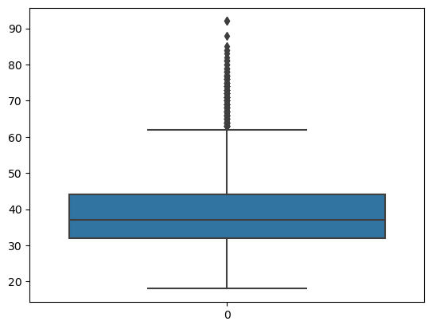

```python
sns.boxplot(data=df['age'])
```

There appears to be outliers within the age column. Let's take a look at the statistical summary to get a deeper insight

```python
df['age'].describe()
```

```
count    10000.000000
mean        38.921800
std         10.487806
min         18.000000
25%         32.000000
50%         37.000000
75%         44.000000
max         92.000000
Name: age, dtype: float64
```

From the statistical summary above, we see that the oldest customer is 92 years old, with the mean age of customers being 38.92. To assess the severity of this observation as an outlier, we will use the IQR outlier detection and treatment technique as follows:

```python
outlier_index=[]
def outlier_detector(data,column):
    q1=np.quantile(data[column],0.25)
    q3=np.quantile(data[column],0.75)
    iqr=q3-q1
    upper_limit=q3+(1.25*iqr)
    lower_limit=q1-(1.25*iqr)
    return data[(data[column]<lower_limit) |(data[column]>=upper_limit)]

outlier_age=outlier_detector(df,'age')
```

```python
outlier_age['age'].describe()
```

```
count    588.000000
mean      65.821429
std        5.990659
min       59.000000
25%       61.000000
50%       64.000000
75%       70.000000
max       92.000000
Name: age, dtype: float64
```

## Identifying Outliers Using the IQR Technique

```python
# dropping outliers from the DataFrame
df.drop(index=outlier_age.index,axis=0,inplace=True)
```

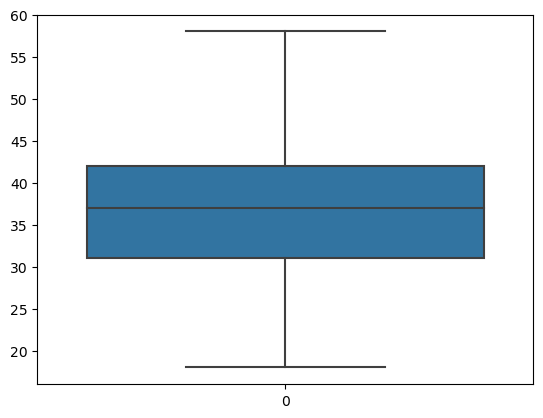

```python
sns.boxplot(data=df['age'])
```

plotting a box plot on the age column after eliminating the outlier observations using IQR technique shw that the column is now free from outliers as shown above.

#### Plot 3: Boxplot for the `tenure` column

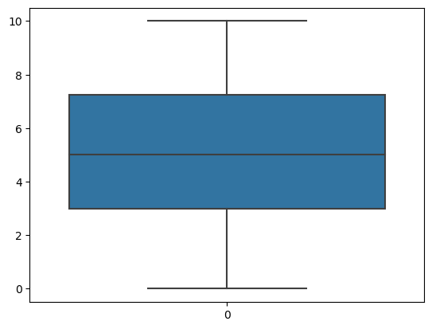

```python
sns.boxplot(data=df['tenure'])
```

```python
df['tenure'].describe()
```

```
count    9412.000000
mean        5.017212
std         2.889551
min         0.000000
25%         3.000000
50%         5.000000
75%         7.250000
max        10.000000
Name: tenure, dtype: float64
```

#### Plot 4: Boxplot for `estimated salary` column

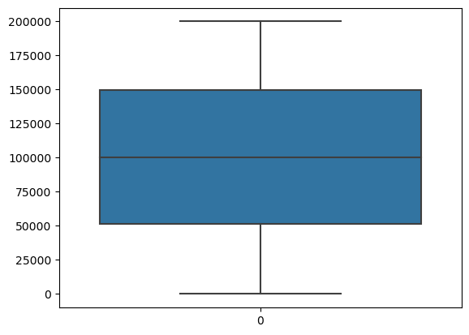

```python
sns.boxplot(data=df['estimatedsalary'])
```

```python
df['estimatedsalary'].describe()
```

```
count      9412.000000
mean     100231.092488
std       57475.669680
min          11.580000
25%       51355.342500
50%      100438.025000
75%      149400.107500
max      199992.480000
Name: estimatedsalary, dtype: float64
```

## Step 3: Exploratory Data Analysis & Visualization

Under this section, we will explore the relastionship between variables using visualizations we will

1. Univariate visualizations

### 3a. Univariate Analysis

#### 3a (i). Distribution of `crediscore`

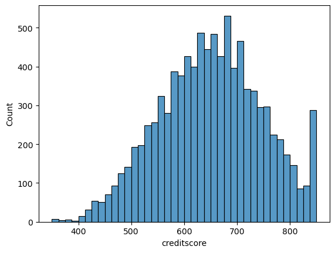

```python
sns.histplot(df['creditscore'])
```

#### 3a (ii). Distribution of customers based on `geography`

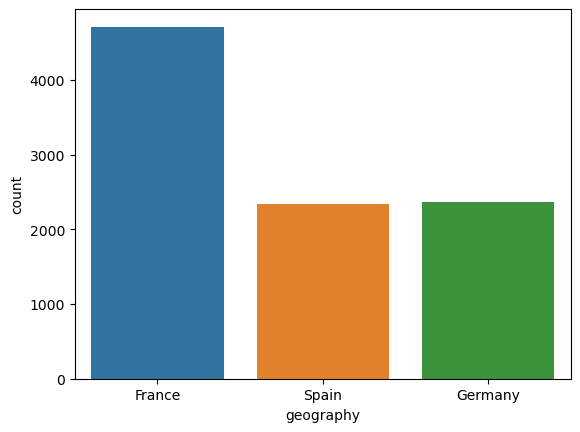

```python
sns.countplot(x=df['geography'])
```

```python
df['geography'].value_counts()
```

```
France     4714
Germany    2361
Spain      2337
Name: geography, dtype: int64
```

The countplot above clearly illustrates the predominant clientele of the bank, with the largest proportion originating from France (4,714 clients), trailed by Germany (2,361 clients), and Spain (2,337 clients).

#### 3a (iii). Distribution of customers based on `gender`

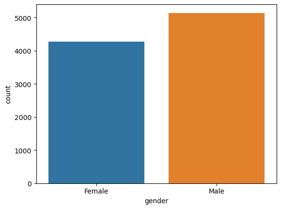

```python
sns.countplot(x=df['gender'])
```

```python
df['gender'].value_counts()
```

```
Male      5138
Female    4274
Name: gender, dtype: int64
```

Analyzing the Count plot depicted above, we discern a notable gender distribution among the bank's clientele. Specifically, the data highlights a higher representation of male clients (5,138), with a slightly lower count of female clients (4,274).

#### 3a (iv). Distribution of customer `tenure`

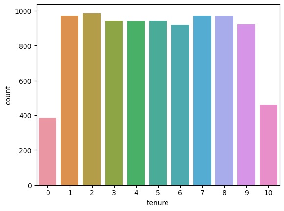

```python
sns.countplot(x=df['tenure'])
```

```python
df.groupby(by='tenure').count()['customerid'].sort_values(ascending=False)
```

```
tenure
2     986
7     972
8     972
1     970
3     943
5     943
4     941
9     920
6     917
10    461
0     387
Name: customerid, dtype: int64
```

The count plot above effectively presents the distribution of customer tenures at the bank, as demonstrated in the following table. The data has been organized in descending order, revealing that a significant portion of customers maintained a 2-year tenure (986 customers), closely pursued by both 7 and 8 years, each accounting for 972 customers. Interestingly, the shortest tenure observed was for customers who spent less than a year with the bank, amounting to 387 customers—depicting those who departed within their first year.

#### 3a (v). Distribution of customer account `balance` at the bank

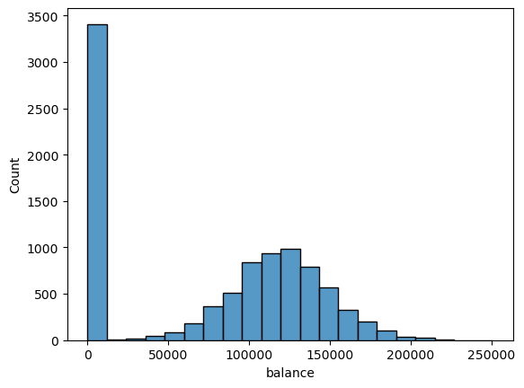

```python
sns.histplot(df['balance'])
```

```python
df[df['balance']>0].balance.describe()
```

```
count      6005.000000
mean     119887.031232
std       30086.624056
min        3768.690000
25%      100212.130000
50%      119787.760000
75%      139561.460000
max      250898.090000
Name: balance, dtype: float64
```

The presented histogram provides an insightful portrayal of the account balance distribution among the bank's customers, reflecting a pattern resembling a normal distribution. Notably, there is a pronounced peak with more than 3,000 customers holding an account balance of $0. Meanwhile, the remaining data points exhibit a symmetrical distribution around the mean value of $119,887.03, underscoring a balanced spread of observations.

#### 3a (v). Distribution of number of Bank products `numofproducts` purchased by customers

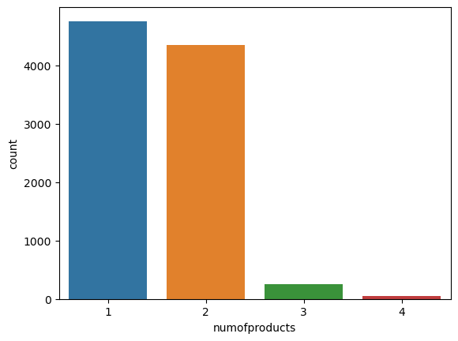

```python
sns.countplot(x=df['numofproducts'])
```

```python
df['numofproducts'].value_counts()
```

```
1    4757
2    4352
3     247
4      56
Name: numofproducts, dtype: int64
```

#### 3a (vi). Distribution of Credit Card ownership `hascrcard` among bank Customers

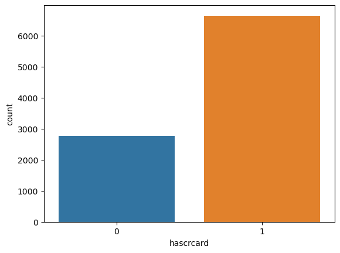

```python
sns.countplot(x=df['hascrcard'])
```

```python
df['hascrcard'].value_counts()
```

```
1    6638
0    2774
Name: hascrcard, dtype: int64
```

The countplot above provides a clear snapshot of the credit card ownership status among the bank's customers. It illustrates that a significant majority, comprising 6,638 customers, possess a credit card, whereas 2,774 customers do not have a credit card in their possession.

#### 3a (vii). Distribution of Bank account status `isactivemember` among customers

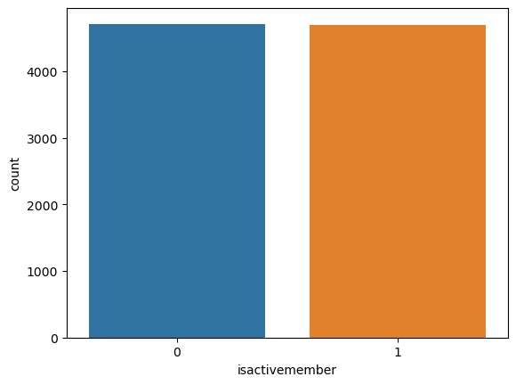

```python
sns.countplot(x=df['isactivemember'])
```

```python
df['isactivemember'].value_counts()
```

```
0    4714
1    4698
Name: isactivemember, dtype: int64
```

The distribution between active and inactive accounts is reasonably balanced, with 4,714 customers identified as inactive members and a closely comparable count of 4,698 customers classified as active members.

#### 3a (viii). Distribution of Customer estimated salary `estimatedsalary`

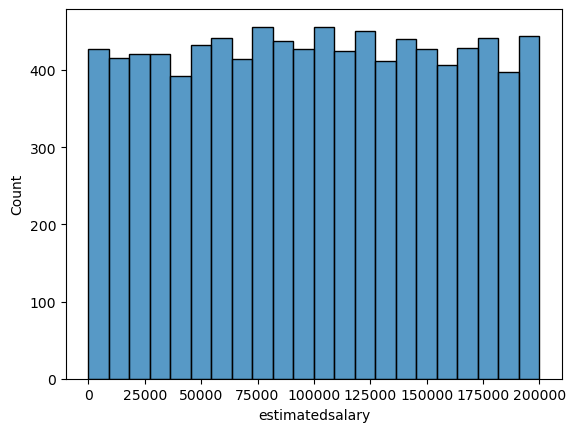

```python
sns.histplot(df['estimatedsalary'])
```

```python
df['estimatedsalary'].describe()
```

```
count      9412.000000
mean     100231.092488
std       57475.669680
min          11.580000
25%       51355.342500
50%      100438.025000
75%      149400.107500
max      199992.480000
Name: estimatedsalary, dtype: float64
```

#### 3a (ix). Distribution of Customer churn `exited`

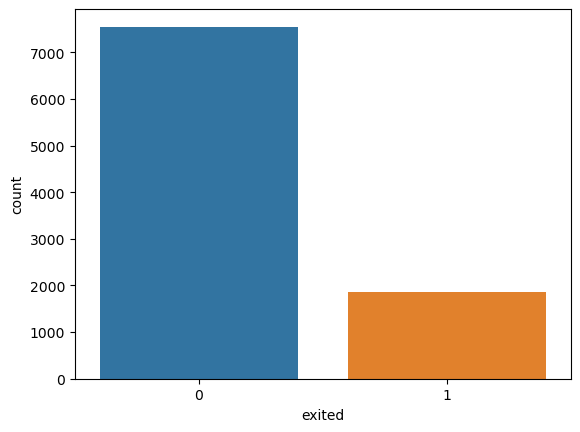

```python
sns.countplot(x=df['exited'])
```

```python
df['exited'].value_counts()
```

```
0    7551
1    1861
Name: exited, dtype: int64
```

The presented countplot offers a clear insight into the bank's customer retention dynamics. It is evident that an overwhelming majority of approximately 7,551 customers chose to maintain their association with the bank throughout the specified duration, while a distinct group of 1,861 customers opted to discontinue their relationship.

#### 3a (x). Distribution of Customer `Satisfaction score`

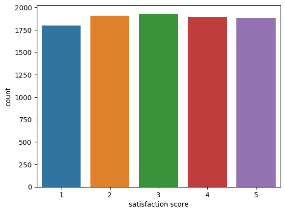

```python
sns.countplot(x=df['satisfaction score'])
```

```python
df['satisfaction score'].value_counts()
```

```
3    1927
2    1910
4    1894
5    1880
1    1801
Name: satisfaction score, dtype: int64
```

The customer satisfaction score serves as an indicator of a customer's assessment of the bank's services. Notably, the most prevalent rating, awarded by 1,927 customers, is 3 points, closely trailed by a rating of 2, which garnered acknowledgment from 1,910 customers. Additionally, the lowest rating of 1 was assigned by 1,801 customers. This pattern underscores a certain degree of consensus in customers' perceptions of the bank's services, contributing to a consistent sentiment across responses.

#### 3a (xi). Distribution of Credit Card type `card type` owned by customers

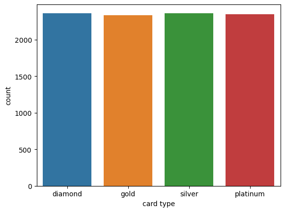

```python
sns.countplot(x=df['card type'])
```

```python
df['card type'].value_counts()
```

```
silver      2365
diamond     2360
platinum    2353
gold        2334
Name: card type, dtype: int64
```

The distribution of customers possessing each of the four card types is notably balanced. The silver card emerges as the most favored selection, drawing the attention of 2,365 customers. In contrast, the gold card experiences relatively fewer takers, with a count of 2,334 customers opting for this option.

#### 3a (xii). Distribution of Points Earned `point earned` by customers

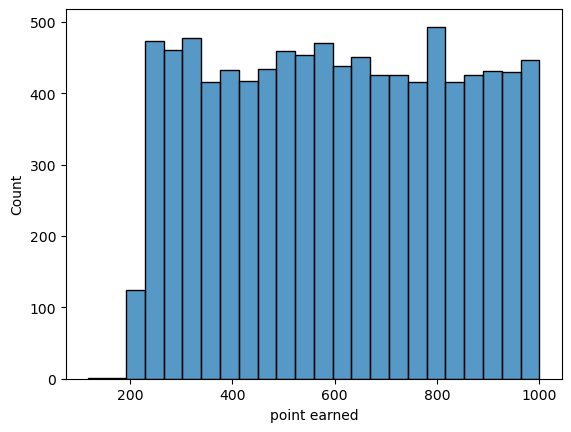

```python
sns.histplot(df['point earned'])
```

```python
df['point earned'].describe()
```

```
count    9412.000000
mean      606.080004
std       226.261205
min       119.000000
25%       410.750000
50%       603.500000
75%       801.000000
max      1000.000000
Name: point earned, dtype: float64
```

The distribution of points earned by customers showcases a uniform pattern, wherein the highest points accumulated stand at 1000 points, and the lowest count is 119 points. The mean point total is calculated at 606.08, accompanied by a standard deviation of 226.26.

### 3b. Multivariate Analysis

#### 3b (i). Distribution of Credit Score `creditscore` among customers by gender

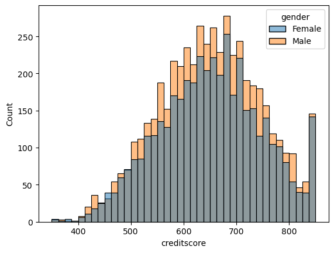

```python
sns.histplot(data=df,x='creditscore',hue='gender')
```

The histogram indicates that the credit score distribution among male and female customers is similar , with both following a normal distribution.

#### 3b (ii). Distribution of customer Credit score `creditscore` by churn status `exited`

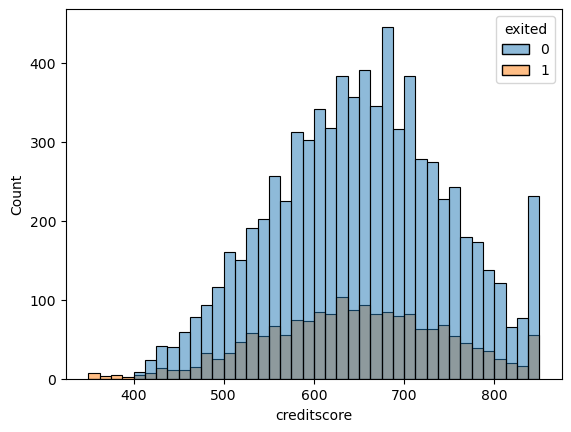

```python
sns.histplot(data=df,x='creditscore',hue='exited')
```

#### 3b (iii). Distribution of customer customer churn `exited` based on their geography `geography`

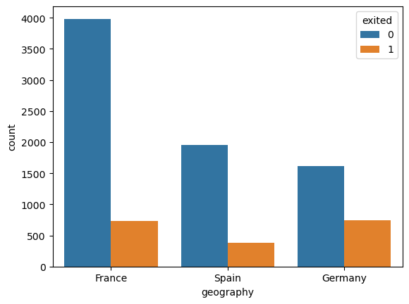

```python
sns.countplot(data=df,x='geography',hue='exited')
```

#### 3b (iii). Distribution of customer churn `exited` across various customer ages `age`

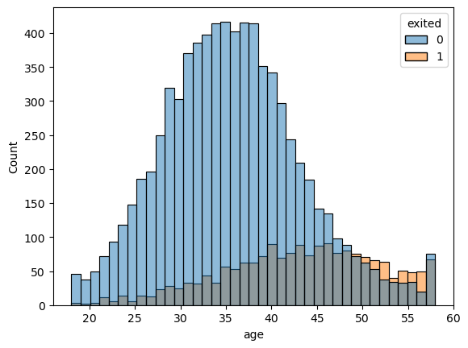

```python
sns.histplot(data=df,x='age',hue='exited')
```

#### 3b (iv). Distribution of customer churn `exited` across various credit card types `card type`

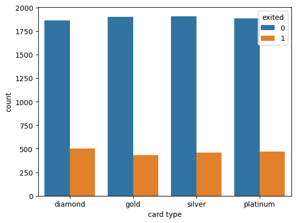

```python
sns.countplot(data=df,x='card type',hue='exited')
```

#### 3b (v). Card ownership `card type` by customer `gender`

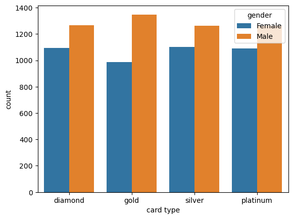

```python
sns.countplot(data=df,x='card type',hue='gender')
```

#### 3b (vi). A scatter plot of `age` vs `creditscore`

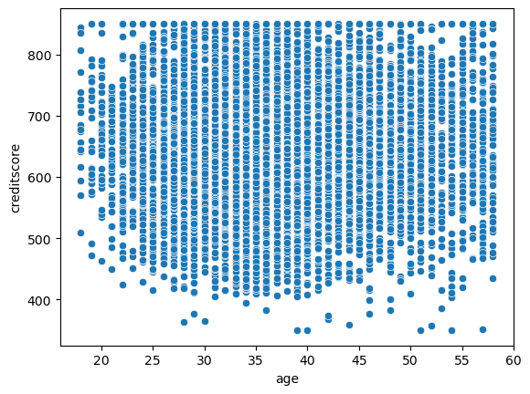

```python
sns.scatterplot(data=df,x='age',y='creditscore')
```

#### 3b (vi). A scatter plot of `age` vs `balance`

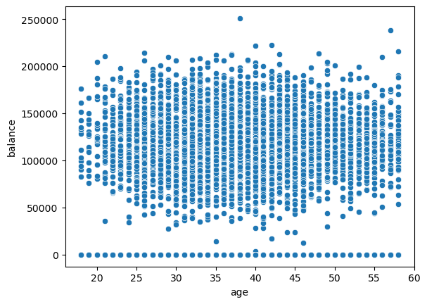

```python
sns.scatterplot(data=df,x='age',y='balance')
```

### 3c. Multivariate Analysis

#### 3c (i). A scatter plot of `age` vs `creditscore` by customer `gender`

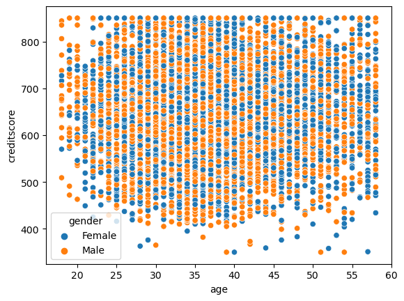

```python
sns.scatterplot(data=df,x='age',y='creditscore',hue='gender')
```

#### 3b (ii). Correlation of `crediscore`,`age`,`balance`,`estimatedsalary`,`point earned`

```python
# Correlation matrix
num_cols=['creditscore','age','balance','estimatedsalary','point earned']
df[num_cols].corr().round(2)
```

|  | creditscore | age | balance | estimatedsalary | point earned |
| --- | --- | --- | --- | --- | --- |
| creditscore | 1.00 | -0.01 | 0.01 | -0.00 | 0.00 |
| age | -0.01 | 1.00 | 0.04 | -0.00 | -0.00 |
| balance | 0.01 | 0.04 | 1.00 | 0.01 | 0.01 |
| estimatedsalary | -0.00 | -0.00 | 0.01 | 1.00 | -0.00 |
| point earned | 0.00 | -0.00 | 0.01 | -0.00 | 1.00 |

The correlation matrix above indicates a weak correlation among the variables, as illustrated in the heatmap below.

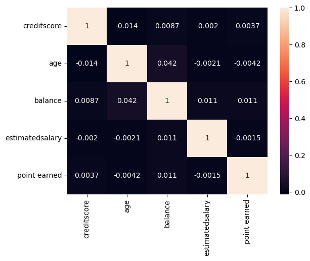

```python
sns.heatmap(df[num_cols].corr(),annot=True)
```

## Step 4: Building the Model

Now that we have understood our data a little better, we will proceed to build our Machine learning models to predict customer churn. Our target variable is the `exited` column. We will build our model with the following steps:

1. Define our x and y variables.
2. Resample our data to eliminate bias in the target group.
3. Build a baseline model with all the features as predictor variables.
4. Obtain predictions from the model.
5. Evaluate the performance of the model.
6. Optimize the model by obtaining kbest features.

### 1. Feature selection

In this section, we'll solely remove the `customerid` column since it doesn't impact our target variable. All other variables will be retained to construct our baseline model.

```python
df.drop(columns=['customerid'],axis=1,inplace=True)
df.head()
```

|  | creditscore | geography | gender | age | tenure | balance | numofproducts | hascrcard | isactivemember | estimatedsalary | exited | complain | satisfaction score | card type | point earned |
| --- | --- | --- | --- | --- | --- | --- | --- | --- | --- | --- | --- | --- | --- | --- | --- |
| 0 | 619 | France | Female | 42 | 2 | 0.00 | 1 | 1 | 1 | 101348.88 | 1 | 1 | 2 | diamond | 464 |
| 1 | 608 | Spain | Female | 41 | 1 | 83807.86 | 1 | 0 | 1 | 112542.58 | 0 | 1 | 3 | diamond | 456 |
| 2 | 502 | France | Female | 42 | 8 | 159660.80 | 3 | 1 | 0 | 113931.57 | 1 | 1 | 3 | diamond | 377 |
| 3 | 699 | France | Female | 39 | 1 | 0.00 | 2 | 0 | 0 | 93826.63 | 0 | 0 | 5 | gold | 350 |
| 4 | 850 | Spain | Female | 43 | 2 | 125510.82 | 1 | 1 | 1 | 79084.10 | 0 | 0 | 5 | gold | 425 |

#### 2. Encoding variables

Our dataset contains categorical variables, specifically `geography`,`gender`,and `card type`, which are not in numerical format. However our machine learning algorithms require numerical inputs for their calculations. Encoding these categorical variables into numerical values allows the algorithm to process and understand the relationships between them and other features in the dataset.

```python
df=pd.get_dummies(df,columns=['geography','gender','card type'],drop_first=True)
df.head()
```

|  | creditscore | age | tenure | balance | numofproducts | hascrcard | isactivemember | estimatedsalary | exited | complain | satisfaction score | point earned | geography_Germany | geography_Spain | gender_Male | card type_gold | card type_platinum | card type_silver |
| --- | --- | --- | --- | --- | --- | --- | --- | --- | --- | --- | --- | --- | --- | --- | --- | --- | --- | --- |
| 0 | 619 | 42 | 2 | 0.00 | 1 | 1 | 1 | 101348.88 | 1 | 1 | 2 | 464 | 0 | 0 | 0 | 0 | 0 | 0 |
| 1 | 608 | 41 | 1 | 83807.86 | 1 | 0 | 1 | 112542.58 | 0 | 1 | 3 | 456 | 0 | 1 | 0 | 0 | 0 | 0 |
| 2 | 502 | 42 | 8 | 159660.80 | 3 | 1 | 0 | 113931.57 | 1 | 1 | 3 | 377 | 0 | 0 | 0 | 0 | 0 | 0 |
| 3 | 699 | 39 | 1 | 0.00 | 2 | 0 | 0 | 93826.63 | 0 | 0 | 5 | 350 | 0 | 0 | 0 | 1 | 0 | 0 |
| 4 | 850 | 43 | 2 | 125510.82 | 1 | 1 | 1 | 79084.10 | 0 | 0 | 5 | 425 | 0 | 1 | 0 | 1 | 0 | 0 |

#### 3. Selecting our X and Y variables

In this analysis, our focus is on predicting customer churn, which is represented by the exited column. This column serves as our target variable – the outcome we want to predict. As we're establishing a baseline model, we will consider all the remaining features in the dataset as our predictor variables. The goal is to utilize these predictor variables to make predictions about customer churn using our baseline mode

```python
x=df[df.columns.drop('exited')] # our predictor variables
y=df['exited'] # our dependent/ target variable
```

#### 4. Splitting Data into train and Test

```python
from sklearn.model_selection import train_test_split
x_train,x_test,y_train,y_test=train_test_split(x,y,test_size=0.20)

x_train,x_val,y_train,y_val=train_test_split(x_train,y_train,test_size=0.20)
```

```python
print(x_train.shape)
print(y_train.shape)
```

```
(6023, 17)
(6023,)
```

```python
print(x_test.shape)
print(y_test.shape)
```

```
(1883, 17)
(1883,)
```

```python
print(x_val.shape)
print(y_val.shape)
```

```
(1506, 17)
(1506,)
```

#### 5. Checking for and Fixing class Imbalance in training data

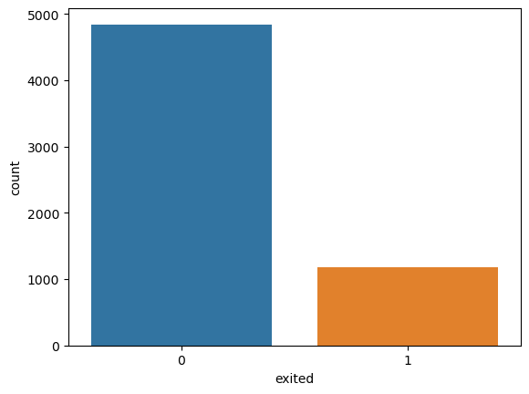

```python
sns.countplot(x=y_train)
```

Undersampling involves reducing the number of instances in the majority class (in this case, class 0) to balance it with the minority class (class 1). This prevents the model from becoming biased towards the majority class and ensures better representation of both classes during training.

The undersampling technique works by randomly selecting a subset of instances from the majority class. This subset is then combined with the instances from the minority class to create a balanced training dataset. By training the model on this balanced data, we encourage it to learn the underlying patterns of both classes more effectively, thus improving its ability to predict the minority class accurately.

```python
import imblearn
from imblearn.under_sampling import RandomUnderSampler
usampler=RandomUnderSampler(replacement=True)
x_train,y_train=usampler.fit_resample(x_train,y_train)
```

#### 5. Building our Baseline model With all features

As mentioned earlier, our approach involves initially constructing a baseline model that incorporates all the predictor variables. Subsequently, we will create a second model with an optimal number of features, determined through the application of the SelectKBest technique.

For our predictive modeling, we have chosen the Support Vector Machine (SVM) model. We will employ this SVM model to make churn predictions and assess the overall performance of both the baseline and feature-selected models.

```python
from sklearn.svm import SVC
svm_model=SVC() # we will use default hyper parameters
svm_model.fit(x_train,y_train)
pred=svm_model.predict(x_test)
```

#### 6. Evaluating our model's Performance

```python
from sklearn.metrics import classification_report
report=classification_report(y_test,pred)
print(report)
```

```
              precision    recall  f1-score   support

           0       0.88      0.39      0.54      1515
           1       0.24      0.79      0.36       368

    accuracy                           0.47      1883
   macro avg       0.56      0.59      0.45      1883
weighted avg       0.76      0.47      0.50      1883
```

### Optimizing Our Model Using Feature Selection

We will use the K-best Method to select the best features to use in our optimized model. This is important because feature selection helps us focus on the most relevant and influential variables, enhancing our model's performance and interpretability.

The `K-best Method`, also known as `SelectKBest`, is a feature selection technique that evaluates the predictive power of different features in a dataset. It ranks the features based on a statistical test, such as the F-test or chi-squared test, which measures the relationship between each feature and the target variable. The method then selects the top "k" features with the highest scores, where "k" is a predefined number.

By choosing the most informative features, the K-best Method helps reduce dimensionality and computational complexity, while maintaining or even improving the model's predictive performance. This process is crucial for enhancing model efficiency and interpretability, as it focuses on the most relevant aspects of the data.

From the resulting plot, we'll identify the value of k that maximizes the F1 score, indicating the optimal number of variables for our model. Once this optimal k is determined, we will use the .get_support() method to extract the corresponding variable values.

Subsequently, we will construct a third model, incorporating these optimal k variables as predictor variables. We will then measure the performance of the optimized model in predicting customer churn.

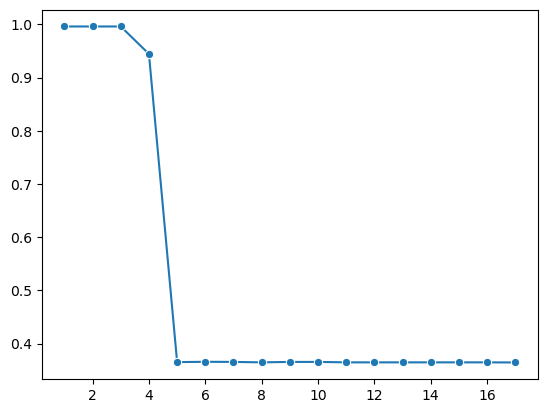

```python
# Importing libraries for feature selection and f1 score
from sklearn.feature_selection import mutual_info_classif,SelectKBest
from sklearn.metrics import f1_score
model=SVC()

f1_scores=[]
for i in range(1,18,1):
    selector=SelectKBest(mutual_info_classif,k=i)
    selector.fit(x_train,y_train)

    sel_x_train=selector.transform(x_train)
    sel_x_test=selector.transform(x_test)

    model.fit(sel_x_train,y_train)
    predv1=model.predict(sel_x_test)

    f1=f1_score(y_test,predv1)
    f1_scores.append(f1)

sns.lineplot(x=range(1,18,1),y=f1_scores,marker='o')
```

From the line plot above, it's evident that the highest F1 score, approaching 1, was achieved when utilizing 3 features. Now, we will proceed to obtain the variable names corresponding to these 3 features as follows:

```python
selector=SelectKBest(mutual_info_classif,k=3)
selector.fit(x_train,y_train)

sel_feature_mask=selector.get_support()
selected_features=x_train.columns[sel_feature_mask]
print(selected_features)
```

```
Index(['age', 'numofproducts', 'complain'], dtype='object')
```

The three most informative variables for our model are `age`, `numofproducts`,`complain`. Let's proceed to construct another model using these features and assess its performance.

```python
svc_model=SVC()

svc_model.fit(x_train[['age','numofproducts','complain']],y_train)
pred2=svc_model.predict(x_val[['age','numofproducts','complain']])

report=classification_report(y_val,pred2)
print(report)
```

```
              precision    recall  f1-score   support

           0       1.00      1.00      1.00      1194
           1       1.00      0.99      1.00       312

    accuracy                           1.00      1506
   macro avg       1.00      1.00      1.00      1506
weighted avg       1.00      1.00      1.00      1506
```

From the classification report above, it's evident that our optimized model achieves a perfect F1 score of 1. This signifies that the model can make precise predictions regarding customer churn solely based on the variables age, numofproducts, and complain.